# Resolución Actividad 3 máster Bioinformática UNIR (2024)

Equipo 2 lote 10 Europa

2025-02-02

**1. Gráficos asociados al PCA y las varianzas acumuladas y explicadas de cada componente principal**

Tras realizar el PCA y la matriz de cargas, se realizaron diferentes gráficos asociados al PCA y la varianza acumulada y explicada de cada componente.

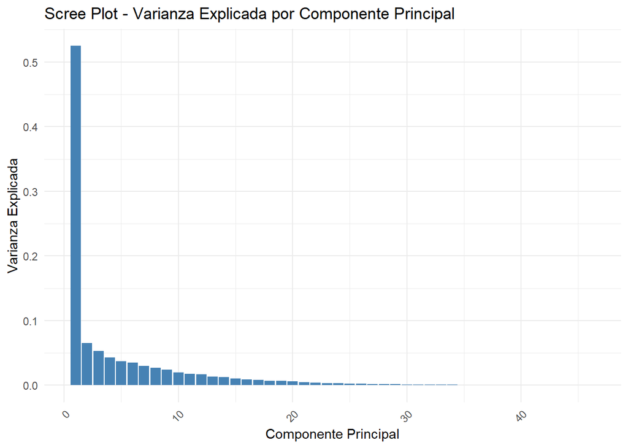

**Figura 1.** Gráfico correspondiente a la varianza explicada por componente principal.

Vemos que con solo los primeros tres componentes principales, puedes retener una proporción significativa (más del 60%) de la varianza, lo que es bastante bueno para reducir la dimensionalidad sin perder demasiada información. PC1 es el componente más importante, explicando más del 50% de la varianza. Los primeros 2-3 componentes explican una proporción considerable de la varianza, y puedes reducir el número de dimensiones manteniendo solo estos primeros componentes. A partir de PC7 en adelante, la varianza explicada por cada componente es marginal y no aporta mucha información relevante.

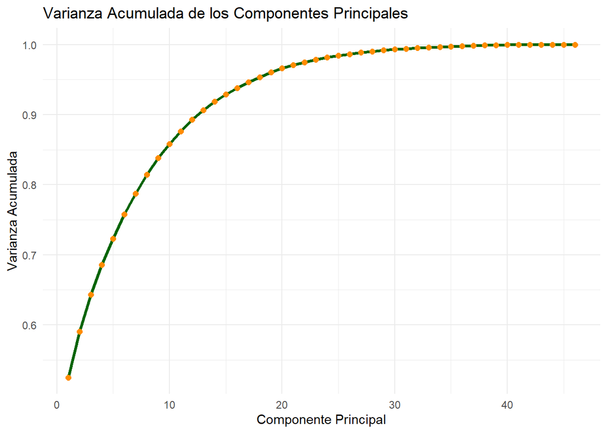

**Figura 2.** Gráfico correspondiente a la varianza acumulada de los diferentes componentes principales.

El gráfico resultante muestra cómo la varianza acumulada aumenta conforme agregas componentes principales. De acuerdo con los valores de R², se espera que la varianza acumulada suba rápidamente al principio (especialmente por el PC1) y luego se estabilice o suba más lentamente a medida que se agregan más componentes.

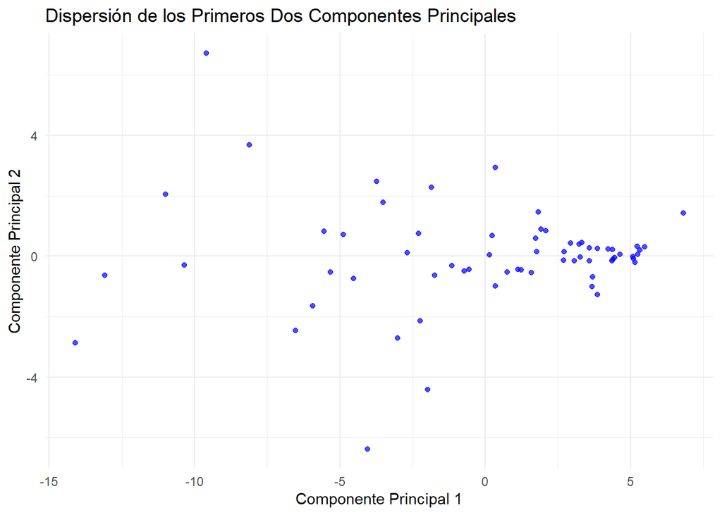

**Figura 3.** Gráfico de dispersion de los componentes principales 1 y 2.

El gráfico de dispersión de los primeros dos componentes principales (PC1 y PC2) muestra cómo se distribuyen los datos a lo largo de las dimensiones más importantes de variabilidad. El eje PC1 captura la mayor parte de la varianza, mientras que PC2 captura menos. Este tipo de visualización permite identificar patrones o agrupaciones en los datos, así como detectar valores atípicos. Si los puntos están bien dispersos o forman grupos, podría indicar que existen estructuras o clusters en los datos. En resumen, es una herramienta para explorar la estructura subyacente y la variabilidad de los datos reducidos a dos dimensiones.

La varianza explicada media por el componente es 0.02, lo que indica que el componente en promedio explica un 2% de la varianza en los datos. La desviación estándar de 0.08 sugiere que esta varianza explicada puede variar bastante entre los diferentes casos de la muestra. Es posible que en algunos casos, la varianza explicada sea mucho más baja o más alta.

Vemos que la varianza acumulada media es 0.92, lo que significa que este componente, junto con los anteriores (si se consideran varios), explica en promedio el 92% de la varianza total en los datos. La desviación estándar de 0.12 muestra que la varianza acumulada varía en torno a este valor, lo que sugiere que la cantidad de varianza explicada por los primeros componentes podría variar algo entre las observaciones.

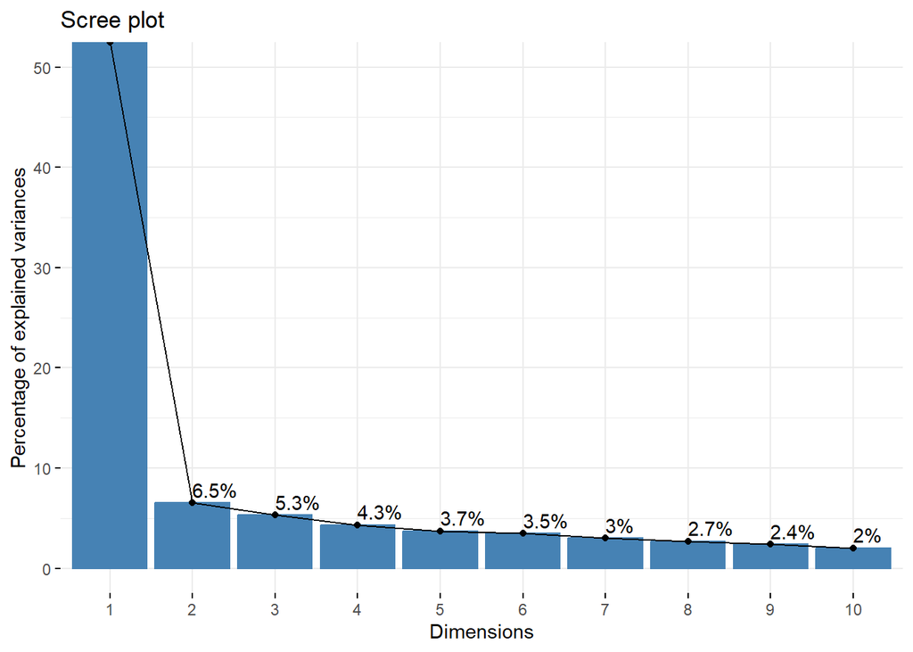

**Figura 5.** Porcentaje de varianza explicada para cada componente principal.

Los eigenvalues (valores propios) miden el nivel de estiramiento o encogimiento de sus vectores asociados tras la transformació de los datos (PCA).

Por tanto, a mayor magnitud del valor propio (%) su dirección asociada (vector propio) mayor información importante contiene.En nuestro contexto, a mayor eigenvalue mayor información de los datos (varianza explicada) contiene la dimensión del PCA.

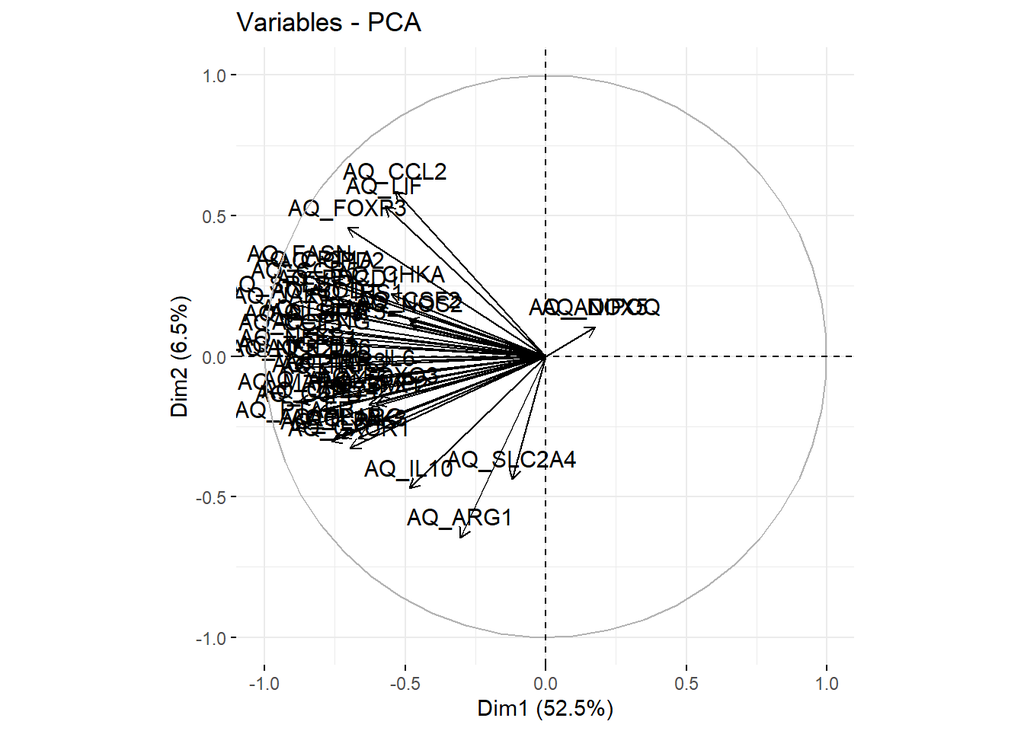

**Figura 6.** Gráfico de correlación y visualización de las diferentes variables con los componentes principales 1 y 2.

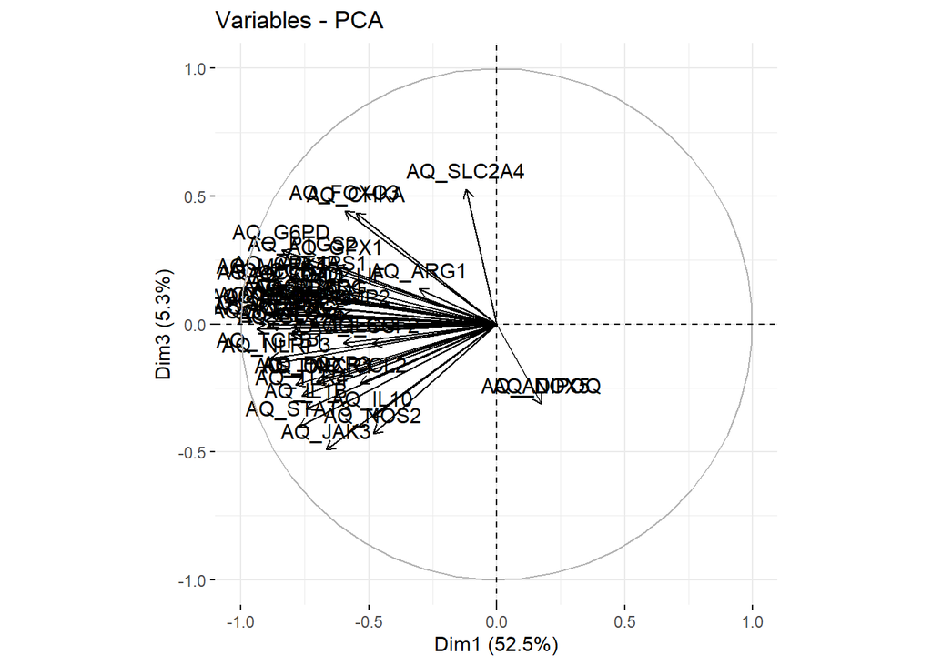

**Figura 7.** Gráfico de correlación y visualización de las diferentes variables con los componentes principales 1 y 3.

La longitud de las flechas indican el grad de correlaciión de la variable con la dimensión. En este caso a tener tantas variables es difíl distinguirlas, ya que los títulos se solapan, pero esta gráfica nos permite ver que variablles (genes) están más relacionados unos con otros.

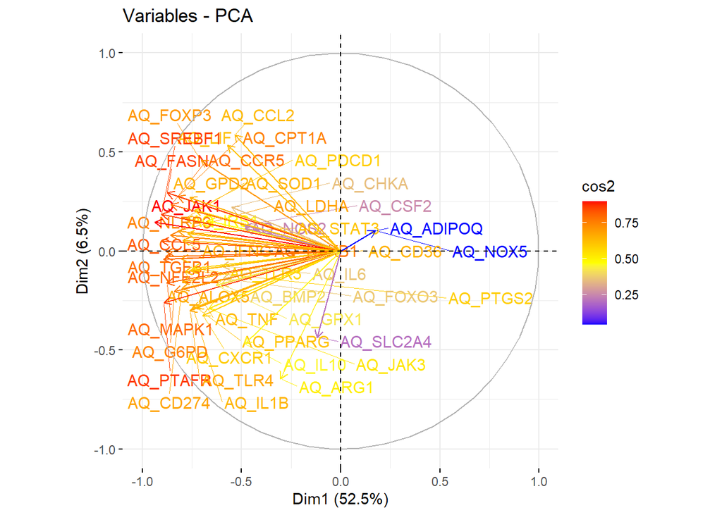

**Figura 8.** Gráfico de correlación de las variables por el coseno (cos2) respecto a los componentes principales 1 y 2.

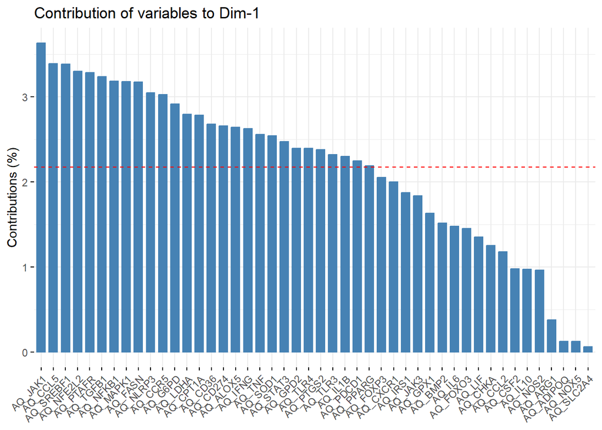

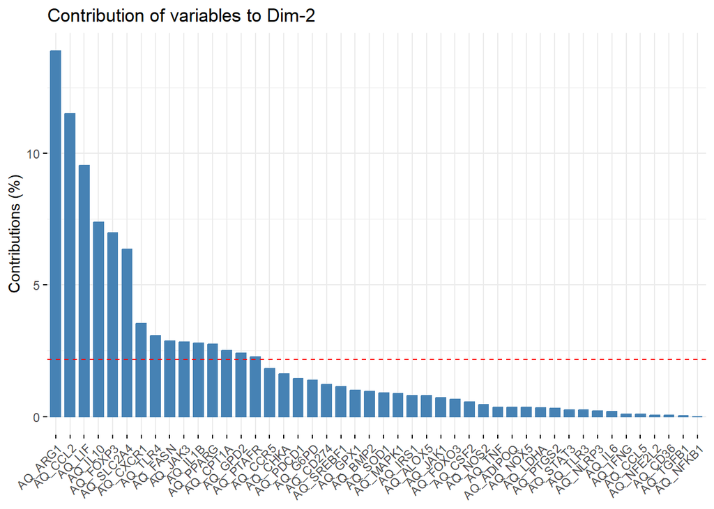

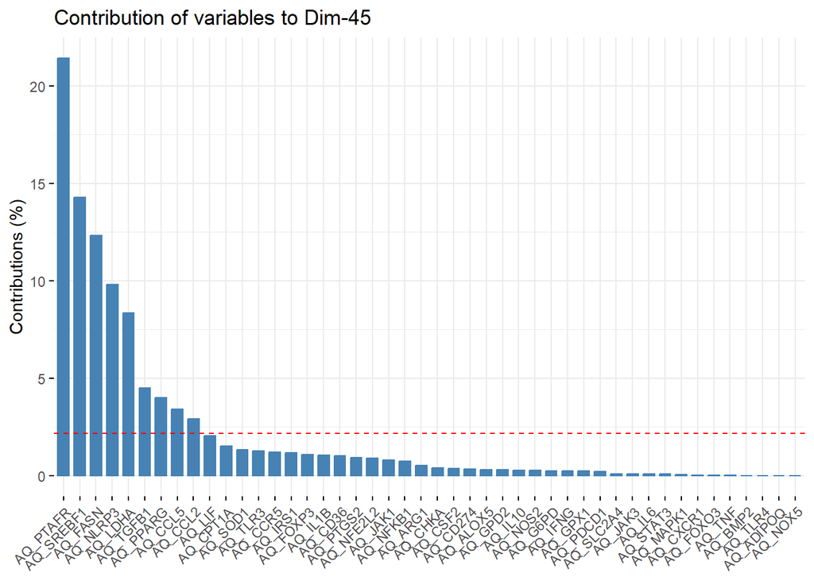

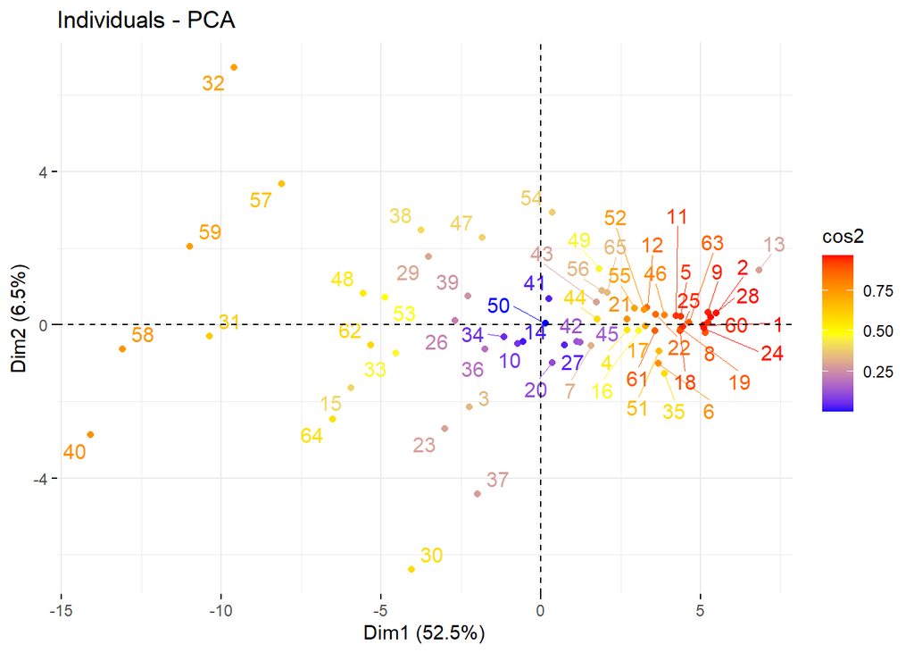

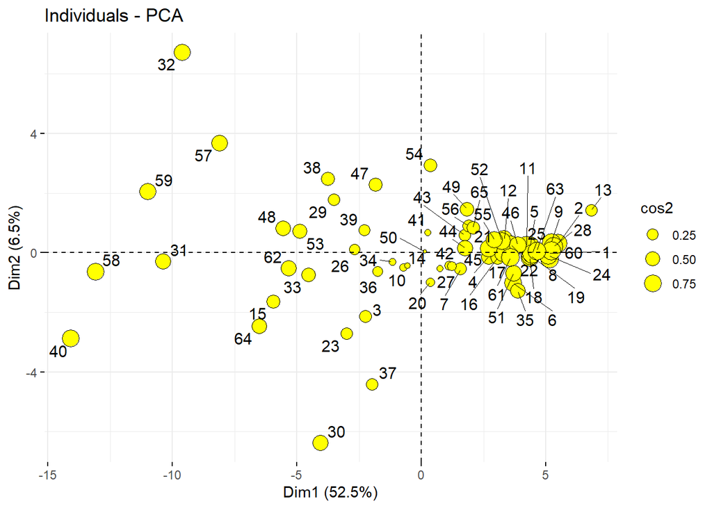

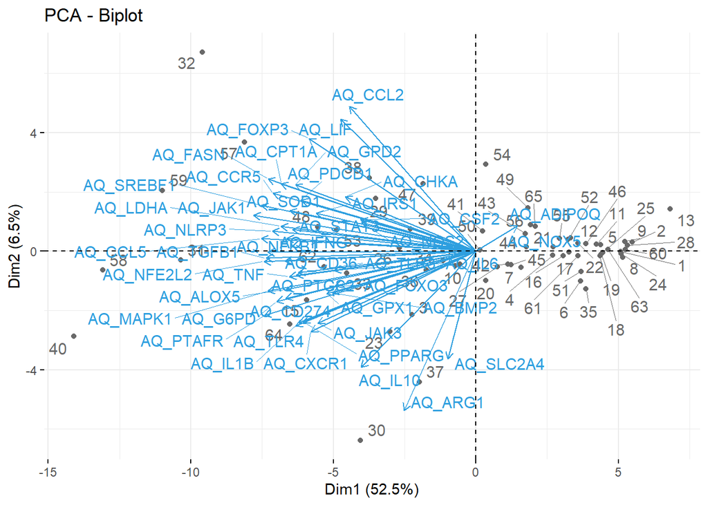

Figuras finales

**2. Tabla descriptiva**

**Componentes principales**

| **Variable** | **Componente principal 1** **T1** N = 22 | **Componente principal 1** **T2** N = 21 | **Componente principal 1** **T3** N = 22 | **Componente principal 1** **p-value**<sup>1</sup> | **Componente principal 2** **T1** N = 22 | **Componente principal 2** **T2** N = 21 | **Componente principal 2** **T3** N = 22 | **Componente principal 2** **p-value**<sup>1</sup> |
| --- | --- | --- | --- | --- | --- | --- | --- | --- |
| AQ_ADIPOQ |  |  |  | 0.110 |  |  |  | 0.417 |
| Mean (SD) | 2.3e-09 (5.5e-09) | 4.2e-10 (5.4e-10) | 4.5e-02 (2.1e-01) |  | 8.6e-10 (1e-09) | 3.5e-10 (3.8e-10) | 4.5e-02 (2.1e-01) |  |
| AQ_ALOX5 |  |  |  | <0.001 |  |  |  | 0.002 |
| Mean (SD) | 1.4e-04 (6.9e-05) | 5.1e-05 (3.6e-05) | 2.1e-05 (1.5e-05) |  | 1e-04 (7.2e-05) | 3.5e-05 (3.4e-05) | 7.1e-05 (7e-05) |  |
| AQ_ARG1 |  |  |  | 0.002 |  |  |  | <0.001 |
| Mean (SD) | 6.8e-06 (7e-06) | 2.9e-06 (3.5e-06) | 2.4e-06 (3.6e-06) |  | 8.4e-06 (6.8e-06) | 1.8e-06 (1.7e-06) | 1.8e-06 (2.8e-06) |  |
| AQ_BMP2 |  |  |  | <0.001 |  |  |  | 0.002 |
| Mean (SD) | 1e-07 (7.6e-08) | 4e-08 (4e-08) | 2e-08 (3.2e-08) |  | 8.1e-08 (7.1e-08) | 3.1e-08 (6.2e-08) | 4.9e-08 (4.6e-08) |  |
| AQ_CCL2 |  |  |  | <0.001 |  |  |  | 0.019 |
| Mean (SD) | 2.5e-07 (2.9e-07) | 9e-08 (1.4e-07) | 1.5e-08 (1.3e-08) |  | 9.1e-08 (1.2e-07) | 4.6e-08 (7e-08) | 2.1e-07 (3.2e-07) |  |
| AQ_CCL5 |  |  |  | <0.001 |  |  |  | 0.004 |
| Mean (SD) | 1.1e-03 (5.9e-04) | 3.6e-04 (2.3e-04) | 1.2e-04 (7.1e-05) |  | 6.9e-04 (5e-04) | 2.8e-04 (4.3e-04) | 5.7e-04 (6.2e-04) |  |
| AQ_CCR5 |  |  |  | <0.001 |  |  |  | <0.001 |
| Mean (SD) | 1.9e-05 (1.2e-05) | 6.6e-06 (3.2e-06) | 2.2e-06 (1.7e-06) |  | 1.1e-05 (1.1e-05) | 3.5e-06 (2.8e-06) | 1.3e-05 (1.2e-05) |  |
| AQ_CD274 |  |  |  | <0.001 |  |  |  | 0.008 |
| Mean (SD) | 3.7e-06 (2e-06) | 1.5e-06 (1.4e-06) | 5.3e-07 (3.9e-07) |  | 3e-06 (2.6e-06) | 1.1e-06 (1.2e-06) | 1.6e-06 (1.2e-06) |  |
| AQ_CD36 |  |  |  | <0.001 |  |  |  | <0.001 |
| Mean (SD) | 5e-05 (1.9e-05) | 2.8e-05 (1.8e-05) | 7.9e-06 (5.1e-06) |  | 4.2e-05 (2.5e-05) | 1.2e-05 (9.4e-06) | 3.1e-05 (2.2e-05) |  |
| AQ_CHKA |  |  |  | <0.001 |  |  |  | 0.010 |
| Mean (SD) | 1.2e-06 (9.7e-07) | 7e-07 (5.1e-07) | 2.8e-07 (4e-07) |  | 8.8e-07 (6.3e-07) | 3.3e-07 (4e-07) | 9.9e-07 (1e-06) |  |
| AQ_CPT1A |  |  |  | <0.001 |  |  |  | 0.007 |
| Mean (SD) | 1.8e-05 (9.5e-06) | 7.1e-06 (5.1e-06) | 2.4e-06 (1.8e-06) |  | 1.1e-05 (8e-06) | 4.3e-06 (4.2e-06) | 1.2e-05 (1.2e-05) |  |
| AQ_CSF2 |  |  |  | 0.004 |  |  |  | 0.400 |
| Mean (SD) | 4.8e-08 (4.6e-08) | 3.4e-08 (4.1e-08) | 7.2e-09 (1.2e-08) |  | 3.1e-08 (3.8e-08) | 1.8e-08 (3.4e-08) | 4e-08 (4.5e-08) |  |
| AQ_CXCR1 |  |  |  | <0.001 |  |  |  | <0.001 |
| Mean (SD) | 3.8e-05 (2.6e-05) | 1.2e-05 (8e-06) | 5e-06 (3.2e-06) |  | 3.1e-05 (2.6e-05) | 8.7e-06 (1.6e-05) | 1.5e-05 (1.4e-05) |  |
| AQ_FASN |  |  |  | <0.001 |  |  |  | 0.001 |
| Mean (SD) | 8.3e-06 (4.3e-06) | 3.4e-06 (1.3e-06) | 7.5e-07 (5.6e-07) |  | 4.5e-06 (3.4e-06) | 2e-06 (3e-06) | 5.8e-06 (4.7e-06) |  |
| AQ_FOXO3 |  |  |  | <0.001 |  |  |  | 0.011 |
| Mean (SD) | 2.9e-04 (1.7e-04) | 1.8e-04 (1.5e-04) | 8e-05 (4.5e-05) |  | 2.8e-04 (2e-04) | 1.3e-04 (8.7e-05) | 1.4e-04 (1.2e-04) |  |

[output cut: 62 more lines]

En este análisis estadístico se formularon las siguientes hipótesis:

Hipótesis nula (H₀): No existen diferencias significativas en la expresión génica entre las diferentes agrupaciones por terciles para el determinado componente principal.

Hipótesis alternativa (H₁): Existen diferencias significativas en la expresión génica entre los diferentes terciles para un mismo componente principal.

Un valor p menor a 0,05 respalda la hipótesis alternativa, indicando la existencia de diferencias significativas en la expresión génica del gen analizado según el tercil dentro de un componente principal específico.

Los resultados muestran que la gran mayoría de variables presentan un valor p significativo en ambos componentes principales, favoreciendo por tanto diferencias significativas en la expresión génica entre los terciles de los componentes principales 1 y 2.

Variables como AQ_ADIPOQ o AQ_NOX5 no presentan diferencias significativas en la expresión génica entre los terciles en ninguno de los 2 componentes principales. Por otro lado, AQ_SLC2A4 solo presenta diferencias significativas en el PC2, mientras que AQ_CSF2, AQ_IL6, AQ_NOS2 y AQ_IFNG, sólo en el PC1.

**3. Modelo de regresión logística**

Por último, se implementó un modelo de regresión logística, utilizando como variable resultado la metástasis (sí/no) y como variables predictoras los terciles de los componentes principales 1, 2 y 3, obtenidos previamente. Además, también se incorporaron otras variables de ajuste relevantes como el sexo o la edad.

```
##
##  0  1
## 18 47
```

```
##
## T1 T2 T3
## 22 21 22
```

```
##
## T1 T2 T3
## 22 21 22
```

```
##
## T1 T2 T3
## 22 21 22
```

```
##
## mujer varon
##    40    25
```

```
##
## CCR  CM  CP
##  29  23  13
```

```
##
## Call:
## glm(formula = metastasis ~ PC1_tercil + PC2_tercil + PC3_tercil +
##     edad + sexo + tumor, family = "binomial", data = data_final_Regresion)
##
## Coefficients:
##               Estimate Std. Error z value Pr(>|z|)
## (Intercept)  -0.455341   2.188352  -0.208    0.835
## PC1_tercilT2 -0.246099   0.750750  -0.328    0.743
## PC1_tercilT3  0.703270   0.945918   0.743    0.457
## PC2_tercilT2  0.925269   0.904381   1.023    0.306
## PC2_tercilT3  0.197685   0.831420   0.238    0.812
## PC3_tercilT2 -0.529150   0.750170  -0.705    0.481
## PC3_tercilT3  0.818372   0.829020   0.987    0.324
## edad          0.001256   0.029625   0.042    0.966
## sexovaron     0.796033   0.672307   1.184    0.236
## tumorCM       0.948649   0.781039   1.215    0.225
## tumorCP       1.042663   0.996418   1.046    0.295
##
## (Dispersion parameter for binomial family taken to be 1)
##
##     Null deviance: 76.703  on 64  degrees of freedom
## Residual deviance: 69.000  on 54  degrees of freedom
## AIC: 91
##
## Number of Fisher Scoring iterations: 4
```

```
##                   2.5 %     97.5 %
## (Intercept)  -4.7562431 3.98208568
## PC1_tercilT2 -1.7469650 1.24329160
## PC1_tercilT3 -1.1372849 2.62676189
## PC2_tercilT2 -0.8067274 2.80404367
## PC2_tercilT3 -1.4172877 1.90146861
## PC3_tercilT2 -2.0612610 0.92630009
## PC3_tercilT3 -0.7869971 2.53396427
## edad         -0.0592852 0.05923954
## sexovaron    -0.4773626 2.20202634
## tumorCM      -0.5367086 2.57059399
## tumorCP      -0.8589554 3.14178772
```

```
##  (Intercept) PC1_tercilT2 PC1_tercilT3 PC2_tercilT2 PC2_tercilT3 PC3_tercilT2
##    0.6342318    0.7818446    2.0203485    2.5225460    1.2185782    0.5891057
## PC3_tercilT3         edad    sexovaron      tumorCM      tumorCP
##    2.2668057    1.0012571    2.2167292    2.5822187    2.8367614
```

```
##  (Intercept) PC1_tercilT2 PC1_tercilT3 PC2_tercilT2 PC2_tercilT3 PC3_tercilT2
##    0.6342318    0.7818446    2.0203485    2.5225460    1.2185782    0.5891057
## PC3_tercilT3         edad    sexovaron      tumorCM      tumorCP
##    2.2668057    1.0012571    2.2167292    2.5822187    2.8367614
```

```
##                   2.5 %    97.5 %
## (Intercept)  0.00859785 53.628770
## PC1_tercilT2 0.17430214  3.467007
## PC1_tercilT3 0.32068855 13.828918
## PC2_tercilT2 0.44631629 16.511278
## PC2_tercilT3 0.24237052  6.695721
## PC3_tercilT2 0.12729336  2.525149
## PC3_tercilT3 0.45520968 12.603370
## edad         0.94243795  1.061029
## sexovaron    0.62041753  9.043320
## tumorCM      0.58466944 13.073588
## tumorCP      0.42360434 23.145207
```

**Tabla de Regresión Logística**

Metástasis (Sí/No) por terciles de PCA

| Variable | OR | IC 95% | P-valor |
| --- | --- | --- | --- |
| (Intercept) | 0.634 | 0.01 - 46.24 | 0.835 |
| PC1_tercilT2 | 0.782 | 0.18 - 3.41 | 0.743 |
| PC1_tercilT3 | 2.020 | 0.32 - 12.9 | 0.457 |
| PC2_tercilT2 | 2.523 | 0.43 - 14.85 | 0.306 |
| PC2_tercilT3 | 1.219 | 0.24 - 6.22 | 0.812 |
| PC3_tercilT2 | 0.589 | 0.14 - 2.56 | 0.481 |
| PC3_tercilT3 | 2.267 | 0.45 - 11.51 | 0.324 |
| edad | 1.001 | 0.94 - 1.06 | 0.966 |
| sexovaron | 2.217 | 0.59 - 8.28 | 0.236 |
| tumorCM | 2.582 | 0.56 - 11.93 | 0.225 |
| tumorCP | 2.837 | 0.4 - 20 | 0.295 |

**Figura 10.** Tabla de regresión logística: Esta tabla contiene los valores OR y p-valores asociados a las variables predictoras (primera columna de la izquierda) con respecto a la variable dependiente (variable de respuesta binaria: presencia o no de metástasis)

Interpretación de resultados:

Terciles de los components principales: Entre los terciles las de las 3 primeros compenentes del PCA podemos destacar el componente 2T2 con un OR de 2.523 y el componente 3T3 con un OR de 2.267, esto podría indicar que los terciles de estos componentes tienen una posible asociación con la aparición de metástasis. Hay que tener en cuenta que el resultado no es estadísticamente significativo, pues el valor nulo ( OR = 1) queda dentro del intervalo de confianza (es decir, el intervalo de confianza no queda por encima o por debajo de este valor nulo) y no presenta un p valor significativo (< 0.05). Por tanto, este resultado debemos tomarlo con precaución.

Sexo: En el sexo varón con respecto al de mujer existe una probabilidad de 2.217 veces mayor de presentar un tumor metastásico. En ningún caso este resultado es estadísticamente significativo pues el valor nulo ( OR = 1) queda dentro del intervalo de confianza (es decir, el intervalo de confianza no queda por encima o por debajo de este valor nulo) y no presenta un p valor significativo (< 0.05). Por tanto, este resultado debemos tomarlo con precaución.

Tipo de tumor: Los pacientes con tumor de tipo cáncer de mama (CM) presentan una probabilidad 2.582 veces superior de tener metástasis con respecto al grupo de pacientes del tumor de referencia (cáncer cole renal, CCR),. En ningún caso este resultado es estadísticamente significativo pues el valor nulo (OR = 1) queda dentro del intervalo de confianza ni presenta p valor significativo (< 0.05). Por tanto, este resultado debemos tomarlo con precaución. Para los pacientes con tumor de tipo cáncer de pulmón (CP) la probabilidad de presentar metástasis con respecto al grupo de referencia es 2.837 veces superior, similar al del grupo CM aunque algo superior. Estos resultados indicarían que CM y CP producen más probabilidad de metástasis que CCR siendo el segundo ligeramente más metastásico. De nuevo, en ningún caso este resultado es estadísticamente significativo pues el valor nulo ( OR = 1) queda dentro del intervalo de confianza y no presenta un p valor significativo (< 0.05). Por tanto, este resultado debemos tomarlo con precaución.